# Are infants sensitive to risk in their intuitive psychology?

Shari Liu

Aug 8 2018

# Figures

[figure not shown]

**Figure 1.** Still frames from videos shown to infants during the experiment. Infants first saw (A) a video of an inanimate object falling off the edge of a shallow, medium and deep cliff. Then, during familiarization (B), infants saw an leap over a shallow but not a medium cliff for one goal (Blue), and a medium but not a deep cliff for the other goal (Yellow). Finally, at test (C), infants saw the agent choose either the goal for which it jumped a shallower cliff (right), or the one for which it jumped a deeper cliff (left).

```r
  return length(unique(data$subj))
```

[output not shown]

| type | N | look | look_norm | sd | se | ci |
| --- | --- | --- | --- | --- | --- | --- |
| Higher Value | 64 | 20.3 | 20.3 | 8.82 | 1.1 | 2.2 |
| Lower Value | 64 | 22.1 | 22.1 | 8.82 | 1.1 | 2.2 |

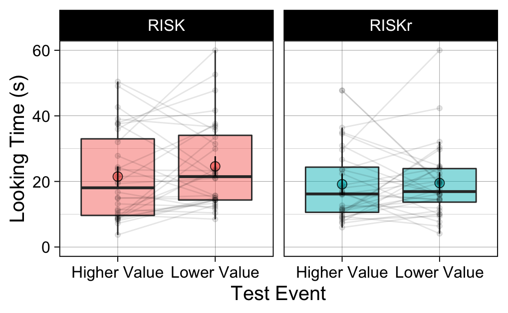

**Figure 2.** Looking time in seconds towards the higher versus lower-value test event. Error bars around means indicate within-subjects 95% confidence intervals. Pairs of points indicate data from a single participant. Horizontal bars within boxes indicate medians, and boxes indicate the middle 2 quartiles of data.

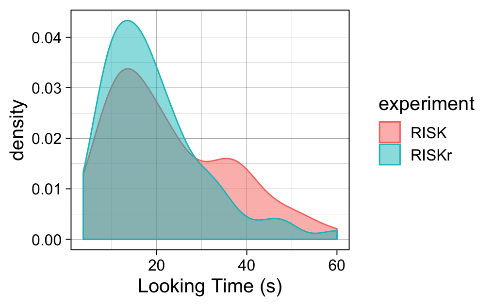

**Figure S1.** Density plot of looking times during test for Experiment 1 (total N=64). Maximum-likelihood fitting revealed that the lognormal distribution (log likelihood=-482) provides a better fit to these data than the normal distribution (log likelihood=-503.702).

# Experiment 1

```r
summary(model2)
```

```
Linear mixed model fit by REML ['lmerMod']
Formula:
loglook ~ type * experiment + (1 | subj) + (1 | experiment)
   Data: risk.avg

REML criterion at convergence: 215

Scaled residuals:
    Min      1Q  Median      3Q     Max
-2.3200 -0.5932 -0.0267  0.6323  1.6355

Random effects:
 Groups     Name        Variance Std.Dev.
 subj       (Intercept) 0.1597   0.400
 experiment (Intercept) 0.0638   0.253
 Residual               0.1775   0.421
Number of obs: 128, groups:  subj, 64; experiment, 2

Fixed effects:
                                Estimate Std. Error t value
(Intercept)                       2.8596     0.2726   10.49
typeLower Value                   0.2119     0.1053    2.01
experimentRISKr                  -0.0694     0.3855   -0.18
typeLower Value:experimentRISKr  -0.1692     0.1489   -1.14

Correlation of Fixed Effects:
            (Intr) typLwV exRISK
typeLowerVl -0.193
exprmntRISK -0.707  0.137
typLVl:RISK  0.137 -0.707 -0.193
convergence code: 0
unable to evaluate scaled gradient
Model failed to converge: degenerate  Hessian with 1 negative eigenvalues
```

In Experiment 1, we tested N=32 10-month-old infants (M=10.133 months, range=9.6-10.633, 14 female), and N=32 13-month-old infants (M=12.887 months, range=12.567-13.467, 17 female).

Overall, infants looked longer at the lower-value actions (M=22.057, SE=1.103) than higher-value actions (M=20.315, SE=1.103), [0.01, 0.293] B=0.152, p=0.019, one-tailed, mixed effect model with fixed effect of test event and random intercepts for participant identity and experiment, excluding one influential participant.

However, when analyzing the two age groups separately, we found that only 13-month-old infants showed this looking preference, [0.019, 0.405] B=0.212, p=0.018, one-tailed, mixed effect model with fixed effect of test event and random intercept for participant identity. In contrast, 10-month-old infants looked equally across the two test events, [-0.182, 0.267], B=0.043, p=0.354, mixed effect model with fixed effect of test event and random intercept for participant identity. Furthermore, these 2 age groups did not significantly differ in looking preference from each other, [-0.461, 0.122], B=-0.169, p=0.26, mixed effects model with fixed interaction between test event and experiment and random intercept for participant identity.